# Scototaxis

Allison Davis

May 6, 2020

## Data collection

```r
library(curl)

raw <- curl("https://raw.githubusercontent.com/allisondavis/scototaxis/master/Scototaxis_raw_cole-data.csv")

raw <- read.csv(raw, header = TRUE, sep = ",", stringsAsFactors = TRUE)

head(raw)
```

```
##   X.U.FEFF.Name    Species Tank Initial_color Dur_white Dur_black Top.B
## 1        Ashley P. formosa    A         Black     174.5     431.9    16
## 2        Ashley P. formosa    B         Black     221.9     381.2    11
## 3         Chloe P. formosa    A         White     188.1     411.5    12
## 4         Chloe P. formosa    B         Black     190.8     422.9    17
## 5          Tory P. formosa    A         Black     195.8     405.4    30
## 6          Tory P. formosa    B         White     221.4     372.0    18
##   Side.B Bot.B Cen.B Top.W Side.W Bot.W Cen.W
## 1     16    11    17    10     10     9     7
## 2     16    21    23     8     15    16    14
## 3     16    21    23     8     10    12     9
## 4     12    16    18    11      9    10    12
## 5     27    25    29    21     19    11    21
## 6     19    33    32     7     13    29    18
```

```r
form <- raw[raw$Species == "P. formosa", ]
head(form)
```

```
##   X.U.FEFF.Name    Species Tank Initial_color Dur_white Dur_black Top.B
## 1        Ashley P. formosa    A         Black     174.5     431.9    16
## 2        Ashley P. formosa    B         Black     221.9     381.2    11
## 3         Chloe P. formosa    A         White     188.1     411.5    12
## 4         Chloe P. formosa    B         Black     190.8     422.9    17
## 5          Tory P. formosa    A         Black     195.8     405.4    30
## 6          Tory P. formosa    B         White     221.4     372.0    18
##   Side.B Bot.B Cen.B Top.W Side.W Bot.W Cen.W
## 1     16    11    17    10     10     9     7
## 2     16    21    23     8     15    16    14
## 3     16    21    23     8     10    12     9
## 4     12    16    18    11      9    10    12
## 5     27    25    29    21     19    11    21
## 6     19    33    32     7     13    29    18
```

```r
lat <- raw[raw$Species == "P. latipinna", ]
head(lat)
```

```
##    X.U.FEFF.Name      Species Tank Initial_color Dur_white Dur_black Top.B
## 21        Finley P. latipinna    A         Black     230.8     368.7    13
## 22        Finley P. latipinna    B         White      71.5     534.2     9
## 23         Tilly P. latipinna    A         Black      92.4     518.0     7
## 24         Tilly P. latipinna    B         Black       0.0     599.9     1
##    Side.B Bot.B Cen.B Top.W Side.W Bot.W Cen.W
## 21     16    18    19    10     13    12     6
## 22      8    12    19     4      2     1     2
## 23     10     9    19     2      4     4    10
## 24      8     4    11     0      0     0     0
```

## Analyses

### First look

Here we will look at summary statistics and visualize our data.

- for now, we will be focusing on duration in each color (black and white).

```r
library(rstatix)
get_summary_stats(form, show = c("mean", "sd", "median", "iqr"))
```

```
## # A tibble: 10 x 6
##    variable      n   mean    sd median   iqr
##    <chr>     <dbl>  <dbl> <dbl>  <dbl> <dbl>
##  1 Bot.B        20  16.8   5.92   16.5  7.75
##  2 Bot.W        20  12.6   5.58   11.5  5.25
##  3 Cen.B        20  16.2   6.74   16.5  7.5
##  4 Cen.W        20  10.2   4.78    9    7
##  5 Dur_black    20 374.   95.2   408.  67.8
##  6 Dur_white    20 232.   92.2   205.  62.2
##  7 Side.B       20  14.6   4.80   15    5
##  8 Side.W       20  12.1   4.05   11.5  5.25
##  9 Top.B        20  14.0   5.10   14    5.5
## 10 Top.W        20   9.45  4.39    9.5  4.25
```

```r
get_summary_stats(lat, show = c("mean", "sd", "median", "iqr"))
```

```
## # A tibble: 10 x 6
##    variable      n   mean    sd median   iqr
##    <chr>     <dbl>  <dbl> <dbl>  <dbl> <dbl>
##  1 Bot.B         4  10.8   5.85   10.5  5.75
##  2 Bot.W         4   4.25  5.44    2.5  5.25
##  3 Cen.B         4  17     4      19    2
##  4 Cen.W         4   4.5   4.43    4    5.5
##  5 Dur_black     4 505.   97.6   526.  70.0
##  6 Dur_white     4  98.7  96.6    82.0 73.4
##  7 Side.B        4  10.5   3.79    9    3.5
##  8 Side.W        4   4.75  5.74    3    4.75
##  9 Top.B         4   7.5   5       8    4.5
## 10 Top.W         4   4     4.32    3    4
```

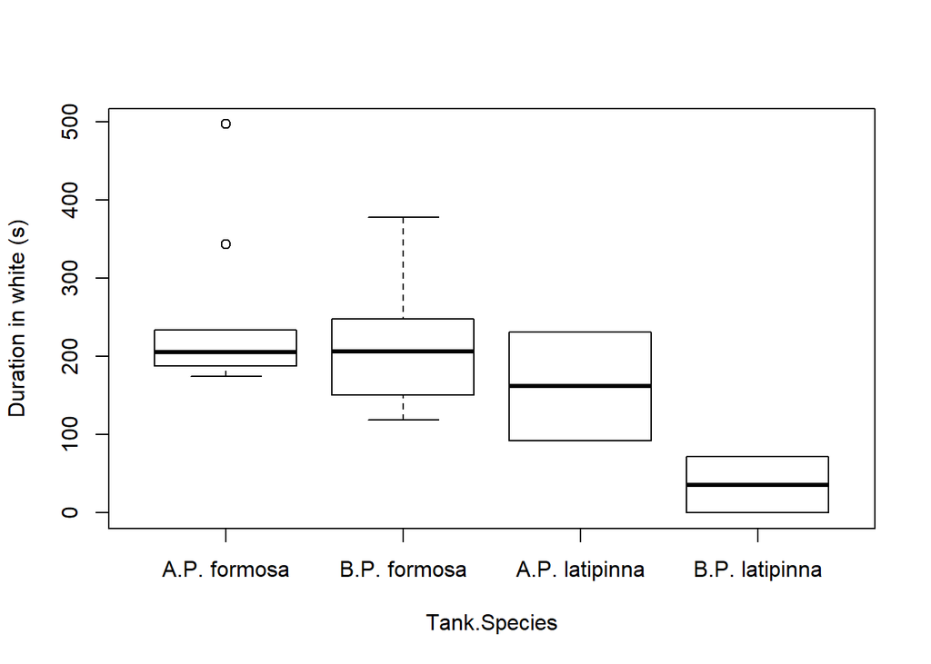

```r
boxplot(data=raw, Dur_white ~ Tank * Species, xlab= "Tank.Species", ylab= "Duration in white (s)")
```

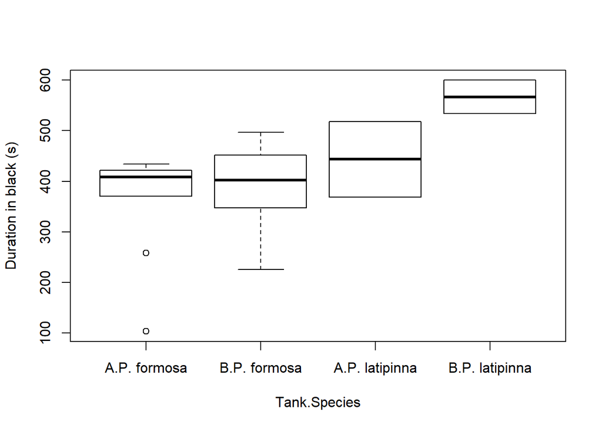

```r
boxplot(data=raw, Dur_black ~ Tank * Species, xlab= "Tank.Species", ylab= "Duration in black (s)")
```

*RESULTS:* From the box plots, we see that the amazons look consistent between tanks, but the sailfins change their duration in a color across tanks (aka trials). Best to see how this stands statistically.

### Stats

Each fish got 10min trial, and so scoring should be around 600s. While all durations are close to this sum, they’re not exact, so it’s better to work with the proportion of time in each color. Thus we need to add a proportion column.

```r
dur_sums.R <- rowSums(raw[5:6])
raw <- cbind(raw, dur_sums.R)

dur_sums.F <- rowSums(form[5:6])
form <- cbind(form, dur_sums.F)

dur_sums.L <- rowSums(lat[5:6])
lat <- cbind(lat, dur_sums.L)

dur_prop.R <- lapply(raw[5:6], function(x){x/dur_sums.R})
raw <- cbind(raw, dur_prop.R) #creates two columns with same name; use name function below to specify column name
names(raw)[16] <- "dur_prop.W"
names(raw)[17] <- "dur_prop.B"

dur_prop.F <- lapply(form[5:6], function(x){x/dur_sums.F})
form <- cbind(form, dur_prop.F) #creates two columns with same name; use name function below to specify column name
names(form)[16] <- "dur_prop.W"
names(form)[17] <- "dur_prop.B"

dur_prop.L <- lapply(lat[5:6], function(x){x/dur_sums.L})
lat <- cbind(lat, dur_prop.L) #creates two columns with same name; use name function below to specify column name
names(lat)[16] <- "dur_prop.W"
names(lat)[17] <- "dur_prop.B"
```

We now have our proportion data. Since t-tests are not happy with proportions (usually require a transformation of some sort), and since we have a small, non-independent sample size, we’ll use Wilcox signed rank and rank sum tests (rank sum==mann whitney u).

- here, non-independent means that you HAVE to be in either white or black, there’s no neutral option. So if you’re not in black, you’re automatically in white.
- just for funsies, we can check the distribution - they look aight in terms of normality, get wonky on the end for formosa, and surprisingly normal for the 4 points of lat… still, with proportions going to use wilcox tests.

```r
library(car)
```

```r
par(mfrow=c(3,2))
qqp(raw$dur_prop.W, "norm")
```

```
## [1] 15 24
```

```r
qqp(raw$dur_prop.B, "norm")
```

```
## [1] 15 24
```

```r
qqp(form$dur_prop.W, "norm")
```

```
## [1] 15 16
```

```r
qqp(form$dur_prop.B, "norm")
```

```
## [1] 15 16
```

```r
qqp(lat$dur_prop.W, "norm")
```

```
## [1] 1 4
```

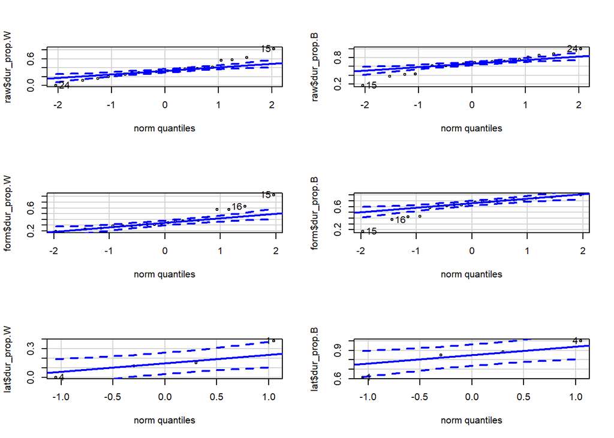

```
## [1] 1 4
```

```r
qqp(lat$dur_prop.B, "norm")
```

#### Wilcox sign rank test

The wilcox sign rank test will be used to determine if there is a difference in proportion of time spent in each color between trials/tanks. Since these are the same individuals, the data is paired (each individual has a proportion in tank A and tank B, we want to see if this differs).

- wilcox.test:
  - when paired=TRUE: performs a signed rank test, testing the null hyp that x-y is symmetric about mu; our null is that x-y (duration in tank A and B) is 0, so mu is 0.
  - when paired=FALSE: performs a rank sum test, testing null hyp that the distributions of x and y differ by a location shift of mu (alt is their shit is something other than mu); again, our null hyp is that the distribution of x and y (form and lat) do not differ, so mu is 0.

```r
wilcox.test(dur_prop.W~Tank, data=form, paired=TRUE)
```

```
##
##  Wilcoxon signed rank test
##
## data:  dur_prop.W by Tank
## V = 35, p-value = 0.4922
## alternative hypothesis: true location shift is not equal to 0
```

```r
wilcox.test(dur_prop.B~Tank, data=form, paired=TRUE)
```

```
##
##  Wilcoxon signed rank test
##
## data:  dur_prop.B by Tank
## V = 20, p-value = 0.4922
## alternative hypothesis: true location shift is not equal to 0
```

```r
wilcox.test(dur_prop.W~Tank, data=lat, paired=TRUE)
```

```
##
##  Wilcoxon signed rank test
##
## data:  dur_prop.W by Tank
## V = 3, p-value = 0.5
## alternative hypothesis: true location shift is not equal to 0
```

```r
wilcox.test(dur_prop.B~Tank, data=lat, paired=TRUE)
```

```
##
##  Wilcoxon signed rank test
##
## data:  dur_prop.B by Tank
## V = 0, p-value = 0.5
## alternative hypothesis: true location shift is not equal to 0
```

*RESULTS:* The proportion in W and B do not differ between tanks A and B within each species. So despite the boxplots looking a bit different between A and B for sailfins, looks like statistically they perform similarly across trials. This means we can average an individuals time in white and time in black for both trials to obtain a single duration in each color for each individaul.

```r
avg.dur_prop.W.R <-aggregate(dur_prop.W~X.U.FEFF.Name, raw, mean)

avg.dur_prop.B.R <-aggregate(dur_prop.B~X.U.FEFF.Name, raw, mean)

raw2 <- cbind(avg.dur_prop.W.R, avg.dur_prop.B.R)
raw2 <- raw2[-c(3)]

#now have a dataframe (raw2) with name, avg dur in W, and avg dur in B --> need spp info too; not sure how to automate

spp <- c("form", "form", "form", "form", "lat", "form", "form", "form", "form", "form", "lat", "form")

raw2 <- cbind(raw2, spp)

#now our dataframe has name, spp, and avg durations

avg.dur_prop.W.F <-aggregate(dur_prop.W~X.U.FEFF.Name, form, mean)

avg.dur_prop.B.F <-aggregate(dur_prop.B~X.U.FEFF.Name, form, mean)

form2 <- cbind(avg.dur_prop.W.F, avg.dur_prop.B.F)
form2 <- form2[-c(3)]

avg.dur_prop.W.L <-aggregate(dur_prop.W~X.U.FEFF.Name, lat, mean)

avg.dur_prop.B.L <-aggregate(dur_prop.B~X.U.FEFF.Name, lat, mean)

lat2 <- cbind(avg.dur_prop.W.L, avg.dur_prop.B.L)
lat2 <- lat2[-c(3)]
```

So we know that the duration in each color doesn’t significantly differ between tanks for each species. Now let’s see if the average duration in each color shows a preference in each speces. Here, we want to see if the average duration in each color (in each species) is different from 0.5 (a 0.5 proportion would mean they spent half their time in white and half in black, thus showing no preference).

```r
wilcox.test(form2$dur_prop.W, mu=0.5)
```

```
##
##  Wilcoxon signed rank test
##
## data:  form2$dur_prop.W
## V = 9, p-value = 0.06445
## alternative hypothesis: true location is not equal to 0.5
```

```r
wilcox.test(form2$dur_prop.B, mu=0.5)
```

```
##
##  Wilcoxon signed rank test
##
## data:  form2$dur_prop.B
## V = 46, p-value = 0.06445
## alternative hypothesis: true location is not equal to 0.5
```

```r
wilcox.test(lat2$dur_prop.W, mu=0.5)
```

```
##
##  Wilcoxon signed rank test
##
## data:  lat2$dur_prop.W
## V = 0, p-value = 0.5
## alternative hypothesis: true location is not equal to 0.5
```

```r
wilcox.test(lat2$dur_prop.W, mu=0.5)
```

```
##
##  Wilcoxon signed rank test
##
## data:  lat2$dur_prop.W
## V = 0, p-value = 0.5
## alternative hypothesis: true location is not equal to 0.5
```

*RESULTS:* it does not seem that either species has a preference for a particular color. Thus, neither species seems to be performing scototaxis: they do not spend more time in the dark portion to protect themselves/out of fear. This is a neat result! Obviously need more sailfin to really say anything, and further analyses of thigmotatic behavior can tell us if they were useing thigmotaxis as a “safety” measure more than the coloration.

The ultimate goal is to determine if the species differ in their durations. *Will be a little awkward since we only have 2 sailfin to our 10 amazons, but we’ll go with it for now.* For this, we’ll use a wilcox sum rank test (aka mann whitney u), since we’re looking for differences between two groups, but this time the groups aren’t paired (our groups here are species, not the tanks).

```r
wilcox.test(dur_prop.W~spp, data = raw2, paired=FALSE)
```

```
##
##  Wilcoxon rank sum test
##
## data:  dur_prop.W by spp
## W = 19, p-value = 0.06061
## alternative hypothesis: true location shift is not equal to 0
```

```r
wilcox.test(dur_prop.B~spp, data = raw2, paired=FALSE)
```

```
##
##  Wilcoxon rank sum test
##
## data:  dur_prop.B by spp
## W = 1, p-value = 0.06061
## alternative hypothesis: true location shift is not equal to 0
```

*RESULTS:* got non-significant results for both tests…in fact, got the same p-value (0.06061), so I’m not sure if that’s a result of having so few sailfins or if I did the test wrong. At the moment, it does not seem that the species differ in the amount of time they spend in either color –so not only is there no preference for a color in either speices, the species don’t differ in the lack of preference.

*Still not telling us anything about variation –more analyses to come.*